# Estimates for Bahrain

Identifying changes in the reproduction number, rate of spread, and doubling time during the course of the COVID-19 outbreak whilst accounting for potential biases due to delays in case reporting in Bahrain. These results are impacted by changes in testing effort, increases and decreases in testing effort will increase and decrease reproduction number estimates respectively (see Methods for further explanation).

### Table of Contents

*Using data available up to the:* 2020-04-18

*Note that it takes time for infection to cause symptoms, to get tested for SARS-CoV-2 infection, for a positive test to return and ultimately to enter the case data presented here. In other words, today’s case data are only informative of new infections about two weeks ago. This is reflected in the plots below, which are by date of infection.*

## Summary (estimates as of the 2020-04-08)

*Table 1: Latest estimates (as of the 2020-04-08) of the number of confirmed cases by date of infection, the expected change in daily confirmed cases, the effective reproduction number, the doubling time, and the adjusted R-squared of the exponential fit. The mean and 90% credible interval is shown for each numeric estimate.*

|  | Estimate |
| --- | --- |
| New confirmed cases by infection date | 165 (95 – 241) |
| Expected change in daily cases | Increasing |
| Effective reproduction no. | 1.5 (1.1 – 1.8) |
| Doubling time (days) | 8.7 (4.7 – 54) |
| Adjusted R-squared | 0.54 (0.084 – 0.94) |

## Reported confirmed cases, their estimated date of infection, and time-varying reproduction number estimates

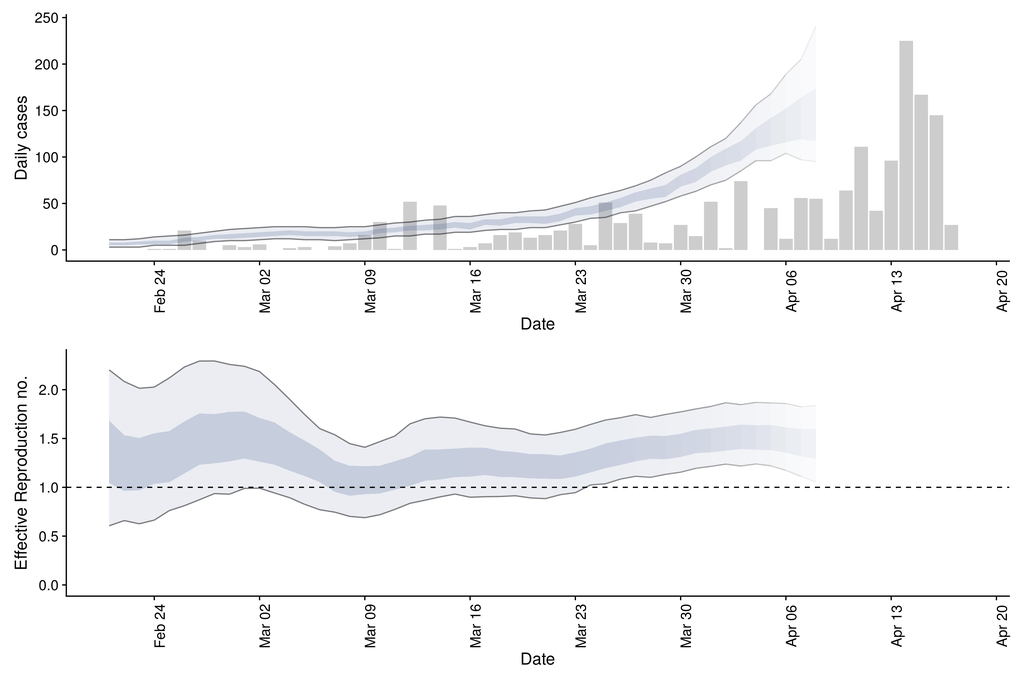

*Figure 1: A.) Confirmed cases by date of report (bars) and their estimated date of infection. B.) Time-varying estimate of the effective reproduction number. Light ribbon = 90% credible interval; dark ribbon = the 50% credible interval. Estimates are shown until the 2020-04-08.Dark grey ribbon = 50% credible interval. Confidence in the estimated values is indicated by translucency with increased translucency corresponding to reduced confidence.*

## Time-varying rate of growth and doubling time

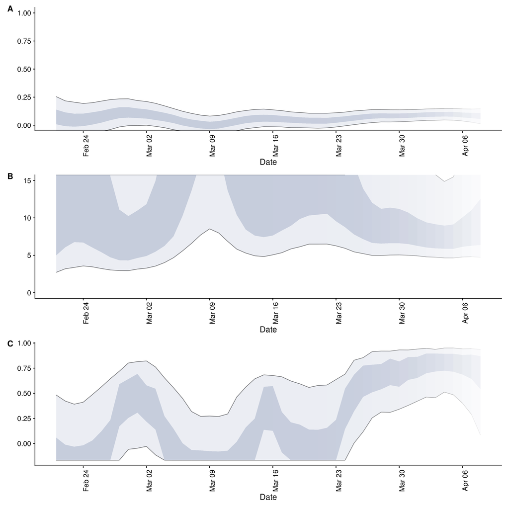

*Figure 2: A.) Time-varying estimate of the rate of growth, B.) Time-varying estimate of the doubling time in days (note that when the rate of growth is negative the doubling time is assumed to be infinite), C.) The adjusted R-squared estimates indicating the goodness of fit of the exponential regression model (with values closer to 1 indicating a better fit). Estimates are shown until the 2020-04-08. Light ribbon = 90% credible interval; dark ribbon = the 50% credible interval. Confidence in the estimated values is indicated by translucency with increased translucency corresponding to reduced confidence.*